# La Junta analysis

Connor Krenzer

2/5/2021

TURN THIS INTO A SHINY APP!!!

If you are looking for a good classification problem, you can try KNN on any of these or do a logistic regression determining whether livestock is a cow or bull.

This is meant to showcase some things that can be done with the data. Even though we have just seven variables, I think you’ll be impressed at what we can do with them…

For starters, I want to bring your attention to the distinct types of cattle and how many of them appear in the data.

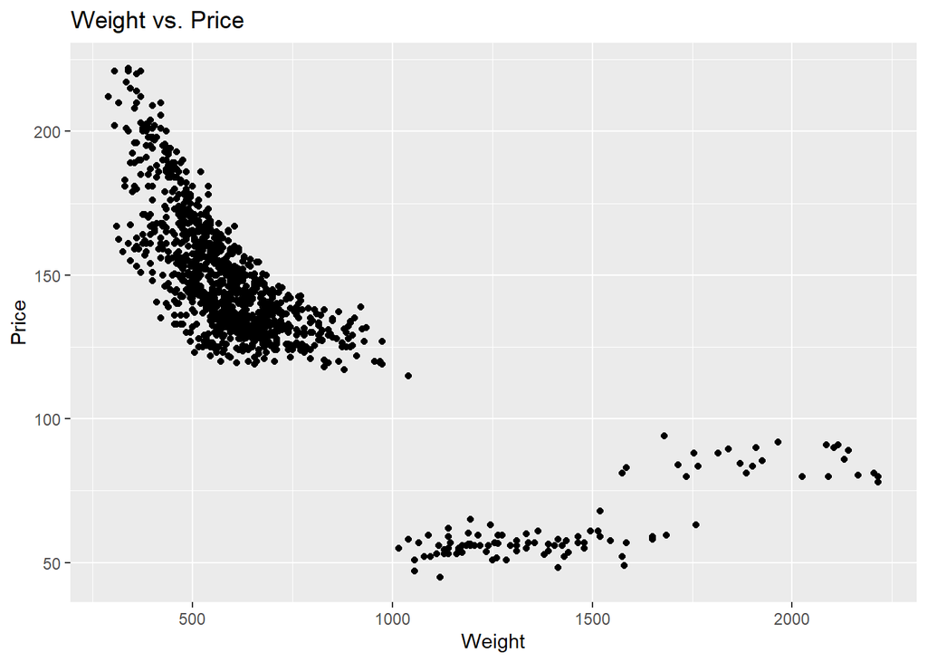

| Reprod | Number of Obs |
| --- | --- |
| bull | 26 |
| cow | 77 |
| hfr | 454 |
| str | 601 |

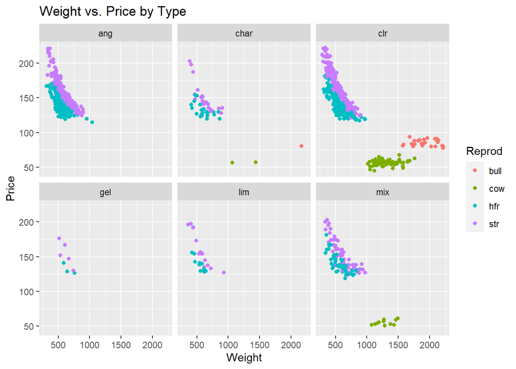

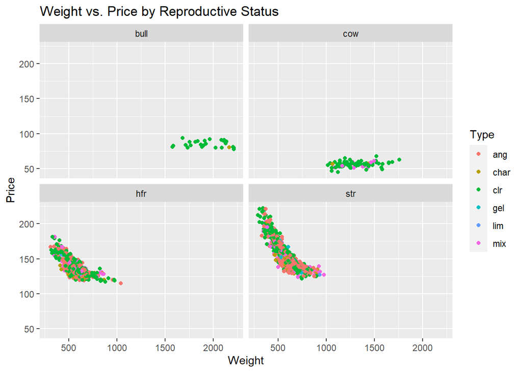

Now, there’s quite a bit that can be said for this information. On my end, it took about 8 hours to get down to six different types of cattle–only to find out that there is basically no difference between the breeds. The reproductive status of the cattle, along with the weight, are what seems to drive the price.